# Teton Temperature Trends

Gordon Gianniny

2023-02-21

## Overview

This script goes contains different analyses testing for trends in stream temperature in the Teton range. It includes the following analyses:

1. Using previously cleaned (by Scott) data - basic lm’s testing the effects of year, air temp, snow pack on average summer (July-August) temperature (designed after the “real time warming…” paper from the Alps).

## 1. lm’s using previously cleaned data:

### A. Data Import and Cleaning

Read in datafiles

```r
ak_basin <- read.csv("Temperature/cleaned_csv/ak_basin_south.csv")
middle_teton <- read.csv("Temperature/cleaned_csv/middle_teton.csv")
n_teton <- read.csv("Temperature/cleaned_csv/n_fork_teton.csv")
paintbrush <- read.csv("Temperature/cleaned_csv/paintbrush.csv")
s_cascade <- read.csv("Temperature/cleaned_csv/s_cascade.csv")
wind_cave <- read.csv("Temperature/cleaned_csv/wind_cave.csv")
```

Re-format data:

```r
#AK Basin:

ak_basin_pivot <- ak_basin %>%
 select(Date, temp_2015:temp_2022)%>% #remove unnecessary cols
  pivot_longer(!c(Date), names_to = "meas_date", values_to = "ak_basin_temp")%>% #pivot longer - make new columns for year and temp, one row for each date for each year
  mutate(year = substr(meas_date,6, 9), #remove "temp_" at beginning of each year to get year column
         dmy_date = paste(Date, year, sep = "-"), #create intermediate date column with year, month, and day
         date_final = as.Date(dmy_date, format = "%d-%b-%Y") #convert intermediate to new date column with as.Date
         )%>%
  select(-meas_date, -dmy_date, -Date)#%>% #remove intermediate/redundant date columns
  #filter(!is.na(date_final)) #remove extra rows with no date

#Middle Teton

middle_teton_pivot <- middle_teton %>%
  select(Date, temp_2015:temp_2022)%>% #remove unnecessary cols
  pivot_longer(!c(Date), names_to = "meas_date", values_to = "mid_teton_temp")%>% #pivot longer - make new columns for year and temp, one row for each date for each year
  mutate(year = substr(meas_date,6, 9), #remove "temp_" at beginning of each year to get year column
         dmy_date = paste(Date, year, sep = "-"), #create intermediate date column with year, month, and day
         date_final = as.Date(dmy_date, format = "%d-%b-%Y") #convert intermediate to new date column with as.Date
         )%>%
  select(-meas_date, -dmy_date, -Date)%>% #remove intermediate/redundant date columns
  filter(!is.na(date_final)) #remove extra rows with no date

# N Teton

n_teton_pivot <- n_teton %>%
  select(Date, temp_2015:temp_2022)%>% #remove unnecessary cols
  pivot_longer(!c(Date), names_to = "meas_date", values_to = "n_teton_temp")%>% #pivot longer - make new columns for year and temp, one row for each date for each year
  mutate(year = substr(meas_date,6, 9),
         dmy_date = paste(Date, year, sep = "-"),
         date_final = as.Date(dmy_date, format = "%d-%b-%Y")
         )%>% #remove "temp_" at beginning of each year
  select(-meas_date, -dmy_date, -Date)%>%
  filter(!is.na(date_final)) #remove extra rows with no date

# Paintbrush

paintbrush_pivot <- paintbrush %>%
 select(Date, temp_2015:temp_2022)%>% #remove unnecessary cols
  pivot_longer(!c(Date), names_to = "meas_date", values_to = "paintbrush_temp")%>% #pivot longer - make new columns for year and temp, one row for each date for each year
  mutate(year = substr(meas_date,6, 9),
         dmy_date = paste(Date, year, sep = "-"),
         date_final = as.Date(dmy_date, format = "%d-%b-%Y")
         )%>% #remove "temp_" at beginning of each year
  select(-meas_date, -dmy_date, -Date)%>%
  filter(!is.na(date_final)) #remove extra rows with no date

# S cascade:

s_cascade_pivot <- s_cascade  %>%
  select(Date, temp_2015:temp_2022)%>% #remove unnecessary cols
  pivot_longer(!c(Date), names_to = "meas_date", values_to = "s_cascade_temp")%>% #pivot longer - make new columns for year and temp, one row for each date for each year
  mutate(year = substr(meas_date,6, 9),
         dmy_date = paste(Date, year, sep = "-"),
         date_final = as.Date(dmy_date, format = "%d-%b-%Y")
         )%>% #remove "temp_" at beginning of each year
  select(-meas_date, -dmy_date, -Date)%>%
  filter(!is.na(date_final)) #remove extra rows with no date

# Wind Cave:

wind_cave_pivot <- wind_cave %>%
  select(Date, Year, Temp)%>%
  rename(year = Year, windcave_temp = Temp)%>%
  mutate(dmy_date = paste(Date, year, sep = "-"),
         date_final = as.Date(dmy_date, format = "%d-%b-%Y"),
         )%>%
  select(-dmy_date, -Date)%>%
  arrange(date_final)
```

Combine into master dataframe:

```r
teton_temps <- merge(middle_teton_pivot, ak_basin_pivot)%>%
  merge(n_teton_pivot)%>%
  merge(paintbrush_pivot)%>%
  merge(s_cascade_pivot)%>%
  merge(wind_cave_pivot, all.x = T) # Merge all 6 sites; all.x command for final merge keeps all 752 obs for each year.
```

Calculate Mean summer (July-Aug, based on “real time warming” paper) temperature for each year by site; reformat for easier plotting:

```r
mean_temps <- teton_temps %>%
  mutate(month = month(date_final))%>% #creating month column
  filter(month == 7|month == 8)%>% #filtering for ONLY July and August
  group_by(year)%>% #group by year
  summarise(
    mid_teton_xbar = mean(mid_teton_temp, na.rm = T),
    ak_basin_xbar = mean(ak_basin_temp, na.rm = T),
    n_teton_xbar = mean(n_teton_temp, na.rm = T),
    paintbrush_xbar = mean(paintbrush_temp, na.rm = T),
    s_cascade_xbar = mean(s_cascade_temp, na.rm = T),
    windcave_xbar = mean(windcave_temp, na.rm = T) #calculate average summer temp for each year, removing missing obs.
  )%>%
  pivot_longer(!year, names_to = "site", values_to = "mean_temp")%>% #pivot longer to get one column for site, one for mean temp, one row for each year
  mutate(year = as.numeric(year)) #recode year column as number instead of character
```

Initial data exploration - plotting:

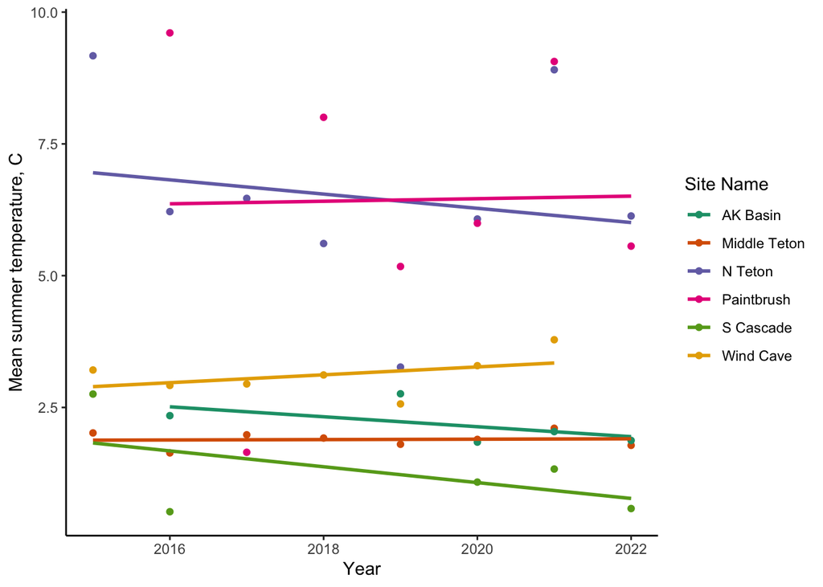

```r
temp.line <- ggplot(mean_temps, aes(x = year, y = mean_temp, color = site))+
  geom_point()+
  geom_smooth(se = F, method = "lm")+
  theme_classic()+
  labs(x = "Year", y = "Mean summer temperature, C", color = "Site Name")+
  scale_color_manual(values = brewer.pal(6, "Dark2"), labels = c("AK Basin", "Middle Teton", "N Teton", "Paintbrush", "S Cascade", "Wind Cave"))
temp.line
```

### B. Testing a linear model for the effects of year within each site:

First, nest data based on site:

```r
temps_nested <- mean_temps %>%
  nest(data = -site) #create new nested dataframe with one column for site, one column for data - data entries for each site include year and mean temp.
```

Next, run a model for each site separately and return a summary table with the results for each site:

```r
temp_models <- temps_nested %>%
  mutate(model = map(data, ~lm(mean_temp~year, data = .)%>% #run a model of temp~year for each site (referenced by "."); store results in new column called "model"
                     tidy))%>% #tidy function to construct a summary table with model results (seperate tables for each site)
  unnest(model) %>% #unnest model column to get rows for each site, columns for model metrics
  filter(term == "year")  #remove intercept term to just get info on year for each site
temp_models
```

```
## # A tibble: 6 × 7
##   site            data             term  estimate std.error statistic p.value
##   <chr>           <list>           <chr>    <dbl>     <dbl>     <dbl>   <dbl>
## 1 mid_teton_xbar  <tibble [8 × 2]> year   0.00366    0.0247    0.148    0.887
## 2 ak_basin_xbar   <tibble [8 × 2]> year  -0.0945     0.0793   -1.19     0.319
## 3 n_teton_xbar    <tibble [8 × 2]> year  -0.135      0.307    -0.439    0.676
## 4 paintbrush_xbar <tibble [8 × 2]> year   0.0243     0.566     0.0430   0.967
## 5 s_cascade_xbar  <tibble [8 × 2]> year  -0.150      0.143    -1.05     0.371
## 6 windcave_xbar   <tibble [8 × 2]> year   0.0747     0.0707    1.06     0.339
```

[figure not shown]

### C. Testing a linear model that includes year, snow pack metrics, and air temperature metrics

#### i. Data import and re-formatting:

First, read in the data: Data from the Phillips Bench and Grand Targhee SNOTEL sites is in “teton_snotel.csv” in the teton_trends project directory (downloaded from the NRCS report generator and edited to remove headers, rename columns in Excel for easier import). This file has:

- Snow-water equivalent (cm)
- Snow depth (cm)
- Air temperature (C)

For April 1st 2015 - March 1st 2023 for both sites. On average, peak snowpack for the Tetons is around April 1st (based on graphic from https://www.tetonconservation.org/snowpack-information ), so will try using April 1st SWE and snow depth as predictor variables.

Data import and some re-formatting:

```r
snotel <- read.csv("teton_snotel.csv")%>% #read in file
  mutate(date = as.Date(date, format = "%m/%d/%y"), #re-code date column as R date obj
         airtemp_c = as.numeric(airtemp_c), #recode air temperature as numeric
         snowdepth_cm = as.numeric(snowdepth_cm))
```

Next, calculate average of both sites by grouping by date, calculating overall means:

```r
snotel_xbars <- snotel %>%
  group_by(date)%>% # group by date
  summarise(swe_xbar  = mean(swe_cm, na.rm = T),
            snowdepth_xbar = mean(snowdepth_cm, na.rm = T),
            airtemp_xbar = mean(airtemp_c, na.rm = T))%>% #calculate means across both sites for each date
 mutate(year = year(date),
        month = month(date),
        day = day(date)) #add columns with year, month, and day
```

End goal = data frame with year, mean summer (July-Aug) air temp, April 1st SWE and April 1st snow depth. Two steps:

1. Get April 1st SWE and snow depth for each year:

```r
snow <- snotel_xbars %>%
  filter(month == 4 & day == 1)%>% #filter out observations for april 1st of each year
  select(year, swe_xbar, snowdepth_xbar)%>% #select year, swe, and snow depth measurements; drop other cols
  rename(swe_apr1 = swe_xbar, snowdepth_apr1 = snowdepth_xbar) #rename swe and snowdepth cols
```

2. Calculate mean summer air temp for each year:

```r
air <- snotel_xbars %>%
  filter(month == 7 | month == 8) %>% #filter for just July and August
  group_by(year) %>% #group by year
  summarise(summertemp_xbar = mean(airtemp_xbar))%>% #calculate mean summer air temp
  select(year, summertemp_xbar) #select year and summer temp for easier merge
```

3. Merge these to get final snotel data, then merge that dataframe with the mean summer stream temps calculated above:

```r
snotel_final <- merge(snow, air) # merge snowpack and air temp info

summer_complete <- merge(mean_temps, snotel_final) #add snowpack and temp info to mean_temps dataframe
```

#### ii. On to modeling:

First pass: what are the visual relationships between stream temperature and SWE, Snow Depth, and summer air temp? What are the trends in these variables over time?

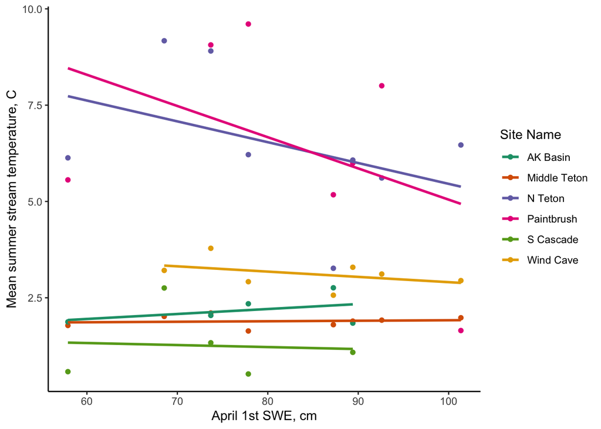

```r
stream.swe <- ggplot(summer_complete, aes(x = swe_apr1, y = mean_temp, color = site))+
  geom_point()+
  geom_smooth(se = F, method = "lm")+
  theme_classic()+
  labs(x = "April 1st SWE, cm", y = "Mean summer stream temperature, C", color = "Site Name")+
  scale_color_manual(values = brewer.pal(6, "Dark2"), labels = c("AK Basin", "Middle Teton", "N Teton", "Paintbrush", "S Cascade", "Wind Cave"))
stream.swe
```

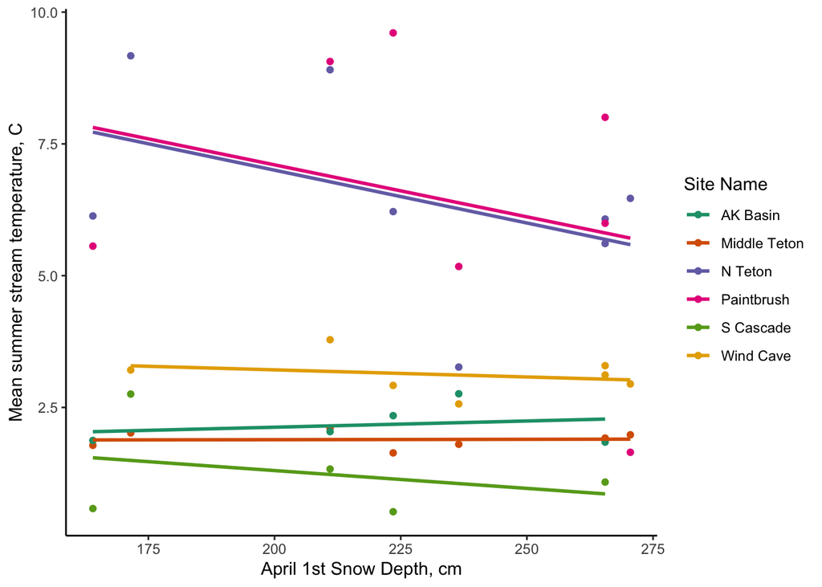

```r
stream.sd <- ggplot(summer_complete, aes(x = snowdepth_apr1, y = mean_temp, color = site))+
  geom_point()+
  geom_smooth(se = F, method = "lm")+
  theme_classic()+
  labs(x = "April 1st Snow Depth, cm", y = "Mean summer stream temperature, C", color = "Site Name")+
  scale_color_manual(values = brewer.pal(6, "Dark2"), labels = c("AK Basin", "Middle Teton", "N Teton", "Paintbrush", "S Cascade", "Wind Cave"))
stream.sd
```

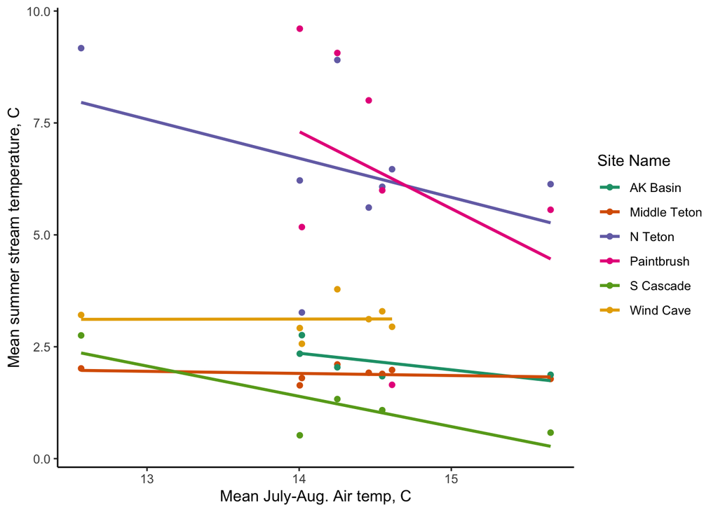

```r
stream.air <- ggplot(summer_complete, aes(x = summertemp_xbar, y = mean_temp, color = site))+
  geom_point()+
  geom_smooth(se = F, method = "lm")+
  theme_classic()+
  labs(x = "Mean July-Aug. Air temp, C", y = "Mean summer stream temperature, C", color = "Site Name")+
  scale_color_manual(values = brewer.pal(6, "Dark2"), labels = c("AK Basin", "Middle Teton", "N Teton", "Paintbrush", "S Cascade", "Wind Cave"))
stream.air
```

First pass: looks like there may be a fairly strong (-) correlation between April 1st SWE/Snow depth and stream temp at N teton and Paintbrush, but probably not in other sites.

Modeling using same approach as above:

Checking for collinearity in predictor variables:

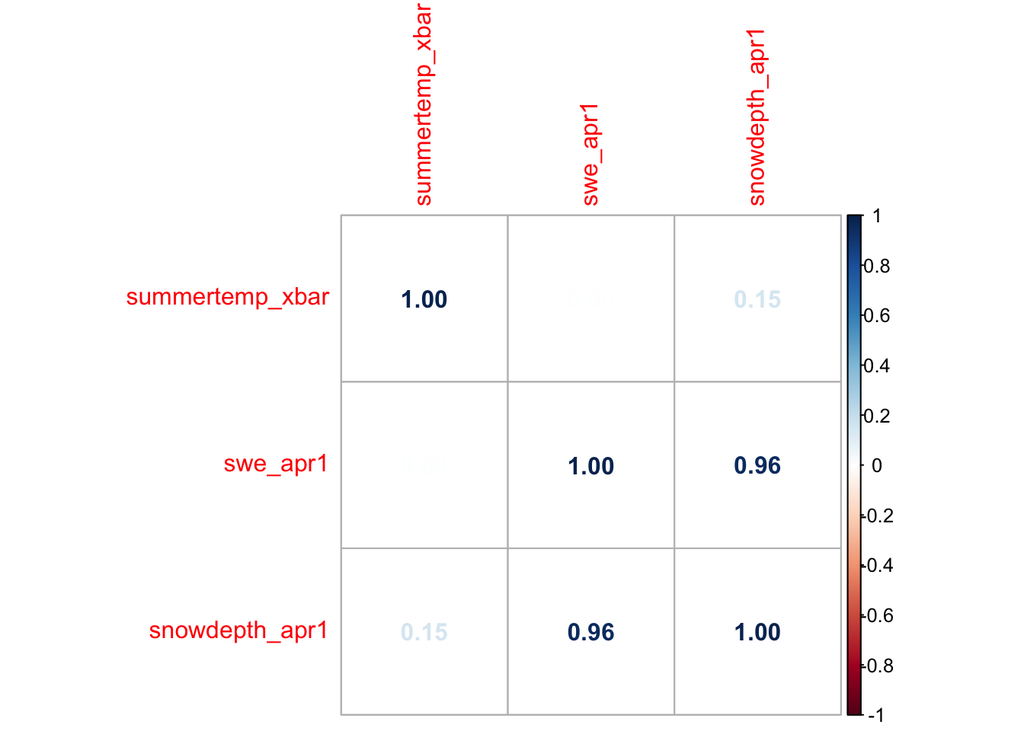

```r
covariates <- summer_complete %>%
  select(summertemp_xbar, swe_apr1, snowdepth_apr1) # New dataframe with just covariates of interest

M <- cor(covariates) #calculate correlation matrix with the "cor" function (stats package)

corrplot(M, method = "number") #plot the correlation matrix with the corrplot package
```

Strong correlation between snow depth and swe (no surprise), so can only include one at a time.

**Modeling**:

First, nest data based on site:

```r
summer_nested <- summer_complete %>%
  nest(data = -site) #create new nested dataframe with one column for site, one column for data - data entries for each site include year and mean temp.
```

Next, run a model for each site separately and return a summary table with the results for each site:

```r
summer_models <- summer_nested %>%
  mutate(model = map(data, ~lm(mean_temp~swe_apr1+summertemp_xbar, data = .)%>% #run a model of temp~swe and summer temp for each site (referenced by "."); store results in new column called "model"
                     tidy))%>% #tidy function to construct a summary table with model results (seperate tables for each site)
  unnest(model) %>% #unnest model column to get rows for each site, columns for model metrics
  filter(term == "swe_apr1"|term == "summertemp_xbar")  #remove intercept term to just get info on swe and summer temp for each site
summer_models
```

```
## # A tibble: 12 × 7
##    site            data             term        estimate std.e…¹ stati…² p.value
##    <chr>           <list>           <chr>          <dbl>   <dbl>   <dbl>   <dbl>
##  1 mid_teton_xbar  <tibble [8 × 5]> swe_apr1     0.00131 0.00447   0.292  0.782
##  2 mid_teton_xbar  <tibble [8 × 5]> summertemp… -0.0470  0.0738   -0.637  0.552
##  3 ak_basin_xbar   <tibble [8 × 5]> swe_apr1    -0.00529 0.0243   -0.218  0.848
##  4 ak_basin_xbar   <tibble [8 × 5]> summertemp… -0.445   0.448    -0.994  0.425
##  5 n_teton_xbar    <tibble [8 × 5]> swe_apr1    -0.0540  0.0484   -1.12   0.315
##  6 n_teton_xbar    <tibble [8 × 5]> summertemp… -0.871   0.799    -1.09   0.326
##  7 paintbrush_xbar <tibble [8 × 5]> swe_apr1    -0.154   0.0691   -2.22   0.0903
##  8 paintbrush_xbar <tibble [8 × 5]> summertemp… -3.69    1.77     -2.09   0.105
##  9 s_cascade_xbar  <tibble [8 × 5]> swe_apr1    -0.0183  0.0285   -0.644  0.586
## 10 s_cascade_xbar  <tibble [8 × 5]> summertemp… -0.713   0.298    -2.39   0.139
## 11 windcave_xbar   <tibble [8 × 5]> swe_apr1    -0.0328  0.0191   -1.72   0.161
## 12 windcave_xbar   <tibble [8 × 5]> summertemp…  0.412   0.313     1.32   0.259
## # … with abbreviated variable names ¹std.error, ²statistic
```

Marginally significant negative correlation between APR 1st SWE and mean summer temperature at Paintbrush (p = 0.09), not at any other sites; no significant correlations between summer air temp and summer stream temp.

#### iii. Tangent - any trends in snow depth, swe, or summer air temp between 2015-2022?

Plots:

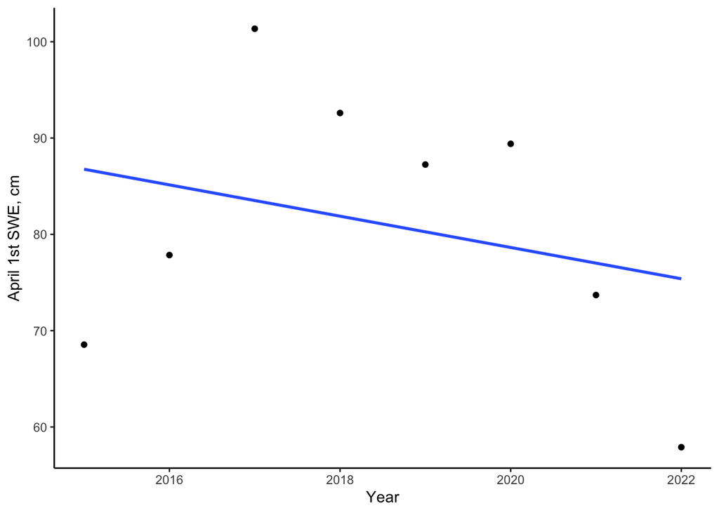

```r
swe.time <- ggplot(snotel_final, aes(x = year, y = swe_apr1))+
  geom_point()+
  geom_smooth(se = F, method = "lm")+
  theme_classic()+
  labs(x = "Year", y = "April 1st SWE, cm")
swe.time
```

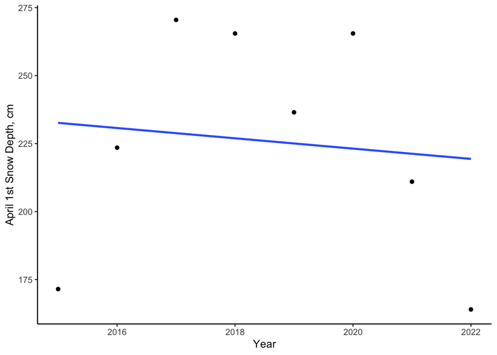

```r
sd.time <- ggplot(snotel_final, aes(x = year, y = snowdepth_apr1))+
  geom_point()+
  geom_smooth(se = F, method = "lm")+
  theme_classic()+
  labs(x = "Year", y = "April 1st Snow Depth, cm")
sd.time
```

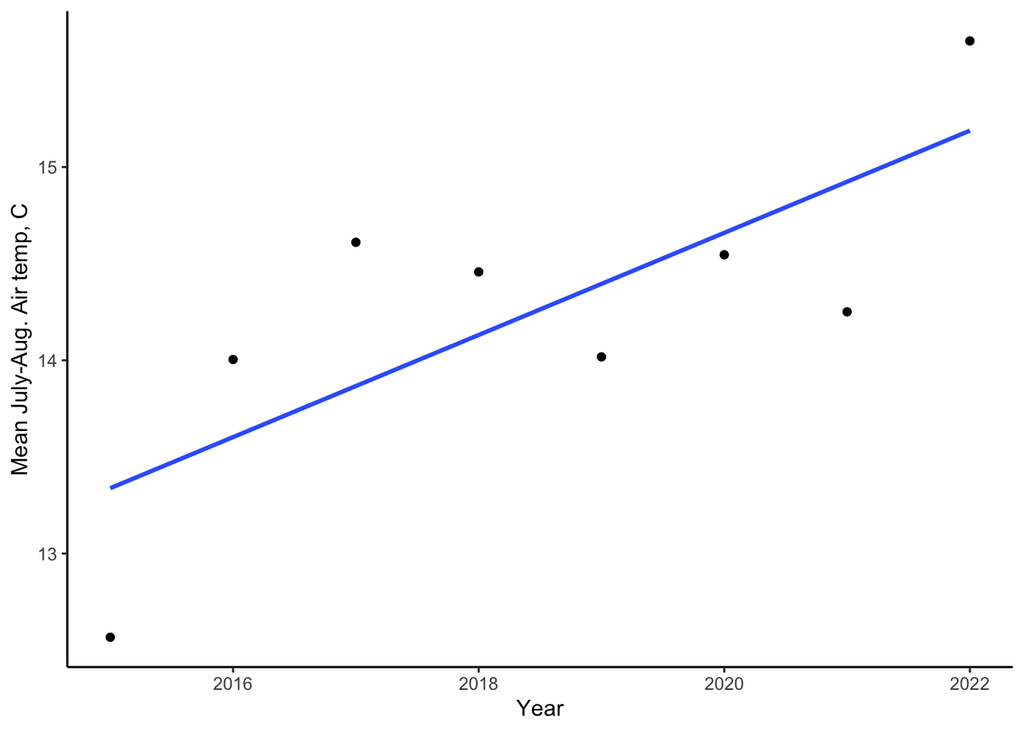

```r
air.time <- ggplot(snotel_final, aes(x = year , y = summertemp_xbar))+
  geom_point()+
  geom_smooth(se = F, method = "lm")+
  theme_classic()+
  labs(x = "Year", y = "Mean July-Aug. Air temp, C")
air.time
```

Looks like there could be a significant increase in air temp, weak decreases in snowpack, but nothing obvious.

Models:

**a. SWE:**

```r
swe.lm <- lm(swe_apr1 ~ year, data = snotel_final)
summary(swe.lm)
```

```
##
## Call:
## lm(formula = swe_apr1 ~ year, data = snotel_final)
##
## Residuals:
##     Min      1Q  Median      3Q     Max
## -18.212  -9.838   1.837  10.725  17.837
##
## Coefficients:
##             Estimate Std. Error t value Pr(>|t|)
## (Intercept) 3361.137   4583.141   0.733    0.491
## year          -1.625      2.271  -0.716    0.501
##
## Residual standard error: 14.71 on 6 degrees of freedom
## Multiple R-squared:  0.07865,    Adjusted R-squared:  -0.07491
## F-statistic: 0.5122 on 1 and 6 DF,  p-value: 0.5011
```

No trend in April 1st SWE

**b. Snow depth:**

```r
sd.lm <- lm(snowdepth_apr1 ~ year, data = snotel_final)
summary(sd.lm)
```

```
##
## Call:
## lm(formula = snowdepth_apr1 ~ year, data = snotel_final)
##
## Residuals:
##     Min      1Q  Median      3Q     Max
## -61.125 -21.545   2.107  39.330  42.339
##
## Coefficients:
##              Estimate Std. Error t value Pr(>|t|)
## (Intercept)  4046.732  13990.377   0.289    0.782
## year           -1.893      6.931  -0.273    0.794
##
## Residual standard error: 44.92 on 6 degrees of freedom
## Multiple R-squared:  0.01228,    Adjusted R-squared:  -0.1523
## F-statistic: 0.07458 on 1 and 6 DF,  p-value: 0.7939
```

No trend in snow depth.

**c. Summer air temp:**

```r
air.lm <- lm(summertemp_xbar ~ year, data = snotel_final)
summary(air.lm)
```

```
##
## Call:
## lm(formula = summertemp_xbar ~ year, data = snotel_final)
##
## Residuals:
##     Min      1Q  Median      3Q     Max
## -0.7713 -0.4515  0.1063  0.4172  0.7437
##
## Coefficients:
##               Estimate Std. Error t value Pr(>|t|)
## (Intercept) -519.17813  190.29248  -2.728   0.0343 *
## year           0.26428    0.09427   2.803   0.0310 *
## ---
## Signif. codes:  0 '***' 0.001 '**' 0.01 '*' 0.05 '.' 0.1 ' ' 1
##
## Residual standard error: 0.611 on 6 degrees of freedom
## Multiple R-squared:  0.567,  Adjusted R-squared:  0.4949
## F-statistic: 7.858 on 1 and 6 DF,  p-value: 0.03103
```

Significant (+) trend in air temp between 2015-2022 - warming of +0.26 degrees/year. Interesting that increased summer air temp didn’t result in increased summer stream temp…